# Section 7: Data Analysis in Depth

## 1.3 Playing Moneyball in the NBA

### 1.3.1 NBA Data

Source: https://www.youtube.com/watch?v=WfaKNYR2vAA

```r
library(readr)
NBA <- read.csv("NBA_train.csv")
str(NBA)
```

```
## 'data.frame':    835 obs. of  20 variables:
##  $ SeasonEnd: int  1980 1980 1980 1980 1980 1980 1980 1980 1980 1980 ...
##  $ Team     : Factor w/ 37 levels "Atlanta Hawks",..: 1 2 5 6 8 9 10 11 12 13 ...
##  $ Playoffs : int  1 1 0 0 0 0 0 1 0 1 ...
##  $ W        : int  50 61 30 37 30 16 24 41 37 47 ...
##  $ PTS      : int  8573 9303 8813 9360 8878 8933 8493 9084 9119 8860 ...
##  $ oppPTS   : int  8334 8664 9035 9332 9240 9609 8853 9070 9176 8603 ...
##  $ FG       : int  3261 3617 3362 3811 3462 3643 3527 3599 3639 3582 ...
##  $ FGA      : int  7027 7387 6943 8041 7470 7596 7318 7496 7689 7489 ...
##  $ X2P      : int  3248 3455 3292 3775 3379 3586 3500 3495 3551 3557 ...
##  $ X2PA     : int  6952 6965 6668 7854 7215 7377 7197 7117 7375 7375 ...
##  $ X3P      : int  13 162 70 36 83 57 27 104 88 25 ...
##  $ X3PA     : int  75 422 275 187 255 219 121 379 314 114 ...
##  $ FT       : int  2038 1907 2019 1702 1871 1590 1412 1782 1753 1671 ...
##  $ FTA      : int  2645 2449 2592 2205 2539 2149 1914 2326 2333 2250 ...
##  $ ORB      : int  1369 1227 1115 1307 1311 1226 1155 1394 1398 1187 ...
##  $ DRB      : int  2406 2457 2465 2381 2524 2415 2437 2217 2326 2429 ...
##  $ AST      : int  1913 2198 2152 2108 2079 1950 2028 2149 2148 2123 ...
##  $ STL      : int  782 809 704 764 746 783 779 782 900 863 ...
##  $ BLK      : int  539 308 392 342 404 562 339 373 530 356 ...
##  $ TOV      : int  1495 1539 1684 1370 1533 1742 1492 1565 1517 1439 ...
```

SeasonEnd: Year season ended Playoffs: Binary for whether team made it to playoffs that year W: Season wins PTS: Points scored in regular season oppPTS: Opponents scored in regular season

The variables with an A mean “attempted”. Without an A means it was successful.

FG: Field goals X2P: 2 pointers X3P: 3 pointers FT: Free throws

Note, R doesn’t like when var names begin with a number. This is why there is an X in front of 2P and 3P.

### 1.3.2 Playoffs & Wins

Source: https://www.youtube.com/watch?v=NjnQI6R-fQU

Goal of basektball team: making playoffs.

How many games does a team need to win to make playoffs?

```r
table(NBA$W, NBA$Playoffs)
```

```
##
##       0  1
##   11  2  0
##   12  2  0
##   13  2  0
##   14  2  0
##   15 10  0
##   16  2  0
##   17 11  0
##   18  5  0
##   19 10  0
##   20 10  0
##   21 12  0
##   22 11  0
##   23 11  0
```

[output cut: 46 more lines]

Looking at the data, we can see that a good threshold for making it to the playoffs is around 42 wins. This gives a good chance of making it to the playoffs.

Can we use difference between points scored and points allowed ot predict number of games that a team will win?

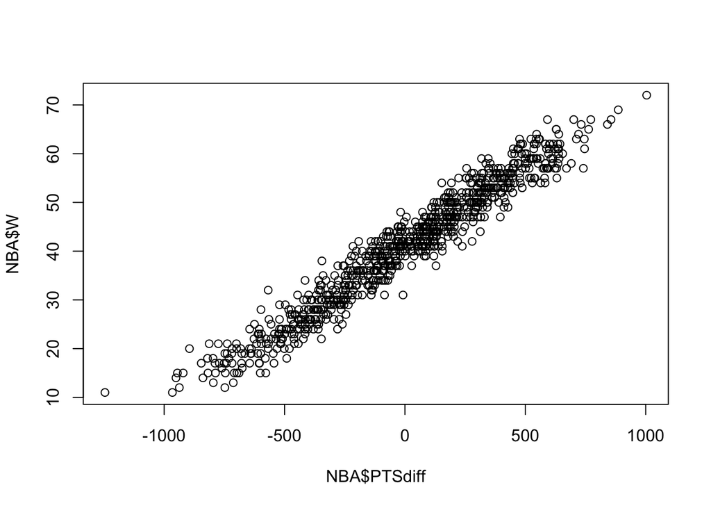

```r
NBA$PTSdiff = NBA$PTS - NBA$oppPTS
plot(NBA$PTSdiff, NBA$W)
```

Suggests a very strong relationship. Linear regression will be a good tool to use.

```r
WinsReg <- lm(W ~ PTSdiff, data=NBA)
summary(WinsReg)
```

```
##
## Call:
## lm(formula = W ~ PTSdiff, data = NBA)
##
## Residuals:
##     Min      1Q  Median      3Q     Max
## -9.7393 -2.1018 -0.0672  2.0265 10.6026
##
## Coefficients:
##              Estimate Std. Error t value Pr(>|t|)
## (Intercept) 4.100e+01  1.059e-01   387.0   <2e-16 ***
## PTSdiff     3.259e-02  2.793e-04   116.7   <2e-16 ***
## ---
## Signif. codes:  0 '***' 0.001 '**' 0.01 '*' 0.05 '.' 0.1 ' ' 1
##
## Residual standard error: 3.061 on 833 degrees of freedom
## Multiple R-squared:  0.9423, Adjusted R-squared:  0.9423
## F-statistic: 1.361e+04 on 1 and 833 DF,  p-value: < 2.2e-16
```

Strong R^2 and very significant variable. Verifies the scatterplot.

We have: $W = 41 + 0.0326PTSdiff$

What PTSdiff do we want to get 42?

Find PTSdiff >= 30.67

### 1.3.3 Points scored

Source: https://www.youtube.com/watch?v=6pcIGhSaSWw

Let’s build an equation to predict points scored using basketball stats. Dep. var: PTS Ind. var. would be common stats, listed above.

```r
PointsReg <- lm(PTS ~ X2PA + X3PA + FTA + AST + ORB + DRB + TOV + STL + BLK, data=NBA)
summary(PointsReg)
```

```
##
## Call:
## lm(formula = PTS ~ X2PA + X3PA + FTA + AST + ORB + DRB + TOV +
##     STL + BLK, data = NBA)
##
## Residuals:
##     Min      1Q  Median      3Q     Max
## -527.40 -119.83    7.83  120.67  564.71
##
## Coefficients:
##               Estimate Std. Error t value Pr(>|t|)
## (Intercept) -2.051e+03  2.035e+02 -10.078   <2e-16 ***
## X2PA         1.043e+00  2.957e-02  35.274   <2e-16 ***
## X3PA         1.259e+00  3.843e-02  32.747   <2e-16 ***
## FTA          1.128e+00  3.373e-02  33.440   <2e-16 ***
## AST          8.858e-01  4.396e-02  20.150   <2e-16 ***
## ORB         -9.554e-01  7.792e-02 -12.261   <2e-16 ***
## DRB          3.883e-02  6.157e-02   0.631   0.5285
## TOV         -2.475e-02  6.118e-02  -0.405   0.6859
## STL         -1.992e-01  9.181e-02  -2.169   0.0303 *
## BLK         -5.576e-02  8.782e-02  -0.635   0.5256
## ---
## Signif. codes:  0 '***' 0.001 '**' 0.01 '*' 0.05 '.' 0.1 ' ' 1
##
## Residual standard error: 185.5 on 825 degrees of freedom
## Multiple R-squared:  0.8992, Adjusted R-squared:  0.8981
## F-statistic: 817.3 on 9 and 825 DF,  p-value: < 2.2e-16
```

Some vars very significant. Others less significant. Decent R^2 value, so there definitely is a linear relationship.

```r
(SSE = sum(PointsReg$residuals^2))
```

```
## [1] 28394314
```

This is very large, but remember this isn’t interpretable. Compute the RMSE instead.

```r
(RMSE = sqrt(SSE/nrow(NBA)))
```

```
## [1] 184.4049
```

This seems like a lot, but the average number of poitns in a season is

```r
mean(NBA$PTS)
```

```
## [1] 8370.24
```

So it isn’t so bad.

But we can still improve our model. Let’s try to remove some vars one at a time.

Let’s start with turnover, TOV. The p-value for the TOV variable was the highest, so it is the least significant.

```r
PointsReg2 <- lm(PTS ~ X2PA + X3PA + FTA + AST + ORB + DRB + STL + BLK, data=NBA)
summary(PointsReg2)
```

```
##
## Call:
## lm(formula = PTS ~ X2PA + X3PA + FTA + AST + ORB + DRB + STL +
##     BLK, data = NBA)
##
## Residuals:
##     Min      1Q  Median      3Q     Max
## -526.79 -121.09    6.37  120.74  565.94
##
## Coefficients:
##               Estimate Std. Error t value Pr(>|t|)
## (Intercept) -2.077e+03  1.931e+02 -10.755   <2e-16 ***
## X2PA         1.044e+00  2.951e-02  35.366   <2e-16 ***
## X3PA         1.263e+00  3.703e-02  34.099   <2e-16 ***
## FTA          1.125e+00  3.308e-02  34.023   <2e-16 ***
## AST          8.861e-01  4.393e-02  20.173   <2e-16 ***
## ORB         -9.581e-01  7.758e-02 -12.350   <2e-16 ***
## DRB          3.892e-02  6.154e-02   0.632   0.5273
## STL         -2.068e-01  8.984e-02  -2.301   0.0216 *
## BLK         -5.863e-02  8.749e-02  -0.670   0.5029
## ---
## Signif. codes:  0 '***' 0.001 '**' 0.01 '*' 0.05 '.' 0.1 ' ' 1
##
## Residual standard error: 185.4 on 826 degrees of freedom
## Multiple R-squared:  0.8991, Adjusted R-squared:  0.8982
## F-statistic: 920.4 on 8 and 826 DF,  p-value: < 2.2e-16
```

Our R^2 is about the same. Goes down very slightly. So we are justified. Next let’s remobe DRB.

```r
PointsReg3 <- lm(PTS ~ X2PA + X3PA + FTA + AST + ORB + STL + BLK, data=NBA)
summary(PointsReg3)
```

```
##
## Call:
## lm(formula = PTS ~ X2PA + X3PA + FTA + AST + ORB + STL + BLK,
##     data = NBA)
##
## Residuals:
##     Min      1Q  Median      3Q     Max
## -523.79 -121.64    6.07  120.81  573.64
##
## Coefficients:
##               Estimate Std. Error t value Pr(>|t|)
## (Intercept) -2.015e+03  1.670e+02 -12.068  < 2e-16 ***
## X2PA         1.048e+00  2.852e-02  36.753  < 2e-16 ***
## X3PA         1.271e+00  3.475e-02  36.568  < 2e-16 ***
## FTA          1.128e+00  3.270e-02  34.506  < 2e-16 ***
## AST          8.909e-01  4.326e-02  20.597  < 2e-16 ***
## ORB         -9.702e-01  7.519e-02 -12.903  < 2e-16 ***
## STL         -2.276e-01  8.356e-02  -2.724  0.00659 **
## BLK         -3.882e-02  8.165e-02  -0.475  0.63462
## ---
## Signif. codes:  0 '***' 0.001 '**' 0.01 '*' 0.05 '.' 0.1 ' ' 1
##
## Residual standard error: 185.4 on 827 degrees of freedom
## Multiple R-squared:  0.8991, Adjusted R-squared:  0.8982
## F-statistic:  1053 on 7 and 827 DF,  p-value: < 2.2e-16
```

Again no change in R^2, so we are justified. Now try removing BLK.

```r
PointsReg4 <- lm(PTS ~ X2PA + X3PA + FTA + AST + ORB + STL, data=NBA)
summary(PointsReg4)
```

```
##
## Call:
## lm(formula = PTS ~ X2PA + X3PA + FTA + AST + ORB + STL, data = NBA)
##
## Residuals:
##     Min      1Q  Median      3Q     Max
## -523.33 -122.02    6.93  120.68  568.26
##
## Coefficients:
##               Estimate Std. Error t value Pr(>|t|)
## (Intercept) -2.033e+03  1.629e+02 -12.475  < 2e-16 ***
## X2PA         1.050e+00  2.829e-02  37.117  < 2e-16 ***
## X3PA         1.273e+00  3.441e-02  37.001  < 2e-16 ***
## FTA          1.127e+00  3.260e-02  34.581  < 2e-16 ***
## AST          8.884e-01  4.292e-02  20.701  < 2e-16 ***
## ORB         -9.743e-01  7.465e-02 -13.051  < 2e-16 ***
## STL         -2.268e-01  8.350e-02  -2.717  0.00673 **
## ---
## Signif. codes:  0 '***' 0.001 '**' 0.01 '*' 0.05 '.' 0.1 ' ' 1
##
## Residual standard error: 185.3 on 828 degrees of freedom
## Multiple R-squared:  0.8991, Adjusted R-squared:  0.8983
## F-statistic:  1229 on 6 and 828 DF,  p-value: < 2.2e-16
```

Same R^2.

This model is a bit simpler. Still have a good R^2. Let’s look at SSE and RMSE again.

Recall

```r
SSE
```

```
## [1] 28394314
```

```r
RMSE
```

```
## [1] 184.4049
```

Now,

```r
(SSE_4 = sum(PointsReg4$residuals^2))
```

```
## [1] 28421465
```

```r
(RMSE = sqrt(SSE_4/nrow(NBA)))
```

```
## [1] 184.493
```

We see that removing the variables has not significantly increased the error in our model. This is good.

### 1.3.4 Making predictions

Source: https://www.youtube.com/watch?v=JNpslqYwDs4

Let’s make predictions for the 2012-2013 season, using our test data set.

```r
NBA_test <- read.csv("NBA_test.csv")
PointsPredictions <- predict(PointsReg4, newdata = NBA_test)
```

Let’s compute the out-of-sample R^2 to see how well this model works. We had a good in-sample R^2, which is about hte training data.

```r
SSE = sum((PointsPredictions - NBA_test$PTS)^2)
SST = sum(((mean(NBA$PTS)-NBA_test$PTS))^2)
(R2 = 1 - SSE/SST)
```

```
## [1] 0.8127142
```

```r
(RMSE = sqrt(SSE/nrow(NBA_test)))
```

```
## [1] 196.3723
```

This isn’t too bad.

# 2 Logistic Regression

## 2.1 Modeling the Expert

## 2.2 The Framingham Heart Study: Evaluating Risk Factors to Save Lives

## 2.3 Election Forecasting: Predicting the Winners Before Any Votes Are Cast

# 3 Clustering

## 3.1 Introduction

## 3.2 Recommendations Worth a Million: Intro to Clustering

## 3.3 Predictive Diagnosis: Discovering Patterns for Disease Recognition

## 3.4 Seeing the Big Picture: Segmenting Images to Create Data

# 4 Model Evaluation: Concepts

# 5 Cross-validation in R

# 6 Trees

## 6.1 Judge, Jury and the Classifier: Intro to Trees

## 6.2 Keeping an Eye on Healthcare Costs

## 6.3 Location, Location, Location: Regressions Trees for Housing Data

# 7 Text Analytics

## 7.1 Introduction

## 7.2 Turning Tweets into Knowledge

## 7.3 Man vs. Machine: How IBM Built a Jeopardy Champion

## 7.4 Predictive Coding: Bring Analytics into the Courtroom